# Compute Metrics

Hope Hahn, Ben Versteeg

2024-04-30

## PART 1: Combined metric

In our combined metric, we will be combining:

- relative error in annual maximum flow estimate
- relative error in monthly flow during high flow period
- correlation between observed and modelled annual maximum flow
- correlation between observed and modelled flow during the high flow period

```r
# read in sager data
sager = read.table("sager.txt", header=T)

# add date
sager = sager %>% mutate(date = paste(day,month,year, sep="/"))
sager$date = as.Date(sager$date,"%d/%m/%Y")

# highest flow month is 5
sager %>%
  group_by(month) %>%
  summarize(mean(obs))
```

```
## # A tibble: 12 × 2
##    month `mean(obs)`
##    <int>       <dbl>
##  1     1       0.741
##  2     2       0.770
##  3     3       1.06
##  4     4       2.17
##  5     5       4.00
##  6     6       2.61
##  7     7       0.750
##  8     8       0.318
##  9     9       0.279
## 10    10       0.347
## 11    11       0.580
## 12    12       0.623
```

```r
source("hope_ben_compute_highflowmetrics_all.R")
```

## PART 2: Calibration

**Read in Data**

Here we read in the data files and prepare them.

We chose to subset the years 1973 and under for calibration.

```r
# multiple results - lets say we've run the model for multiple years, each column
# is streamflow for a different parameter set
msage = read.table("sagerm.txt", header=T)

# label by simulation
nsim = ncol(msage)
snames = sprintf("S%d",seq(from=1, to=nsim))
colnames(msage)=snames

# use the date from the previous dataset
msage$date = sager$date
msage$month = sager$month
msage$year = sager$year
msage$day = sager$day
msage$wy = sager$wy

# lets add observed
msage = left_join(msage, sager[,c("obs","date")], by=c("date"))

# pivot longer
msagel = msage %>%
  pivot_longer(cols=!c(date, month, year, day,wy),
               names_to="run",
               values_to="flow")

# create a subset of data for calibration
msage_calibration <-
  subset(msage, wy <= 1973)
```

**Collect Metrics**

We used our function to collect metrics on the calibration data.

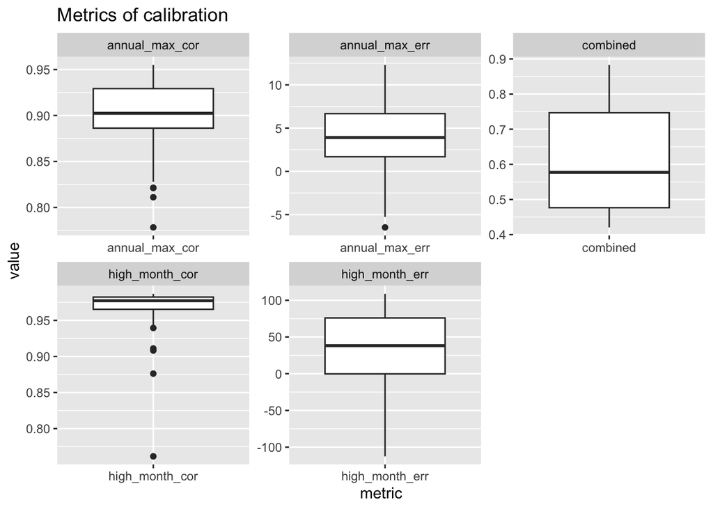

```r
# get metrics
res_calibration = msage_calibration %>%
  select(-date, -month, -day, -year, -wy, -obs) %>%
  # this line applies our function to the dataset
  map_df(compute_highflowmetrics_all,
         o=msage_calibration$obs,
         month=msage_calibration$month,
         day=msage_calibration$day,
         year=msage_calibration$year,
         wy=msage_calibration$wy)

# row that adds simulation number
res_calibration$sim = snames

# graph range of performance measures
resl_calibration = res_calibration %>%
  pivot_longer(-sim,
               names_to="metric",
               values_to="value")

# graph the distribution of metrics over the calibration data
ggplot(resl_calibration, aes(metric, value))+
  geom_boxplot()+
  facet_wrap(~metric, scales="free") +
  labs(title = "Metrics of calibration")
```

**Best and worst simulations**

We plotted the flow of the best simulation by year. Black is the model data and the red line is the observed data.

```r
# best simulation
best_calibration = res_calibration[which.max(res_calibration$combined),]

# get the parameters for worst simulation
worst_calibration = res_calibration[which.min(res_calibration$combined),]

best_calibration$sim
```

```
## [1] "S89"
```

```r
worst_calibration$sim
```

```
## [1] "S15"
```

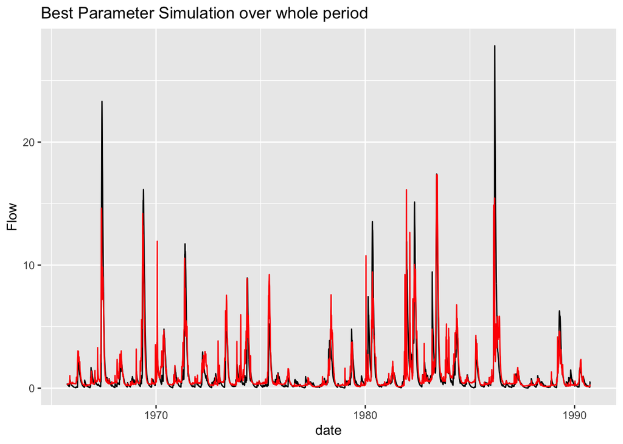

```r
# plot the flow by year for the best parameter
ggplot(msage,
       aes(date, msage[,best_calibration$sim])) +
  geom_line()+
  geom_line(aes(date, obs), col="red")+
  labs(title = "Best Parameter Simulation over whole period",
       y = "Flow")
```

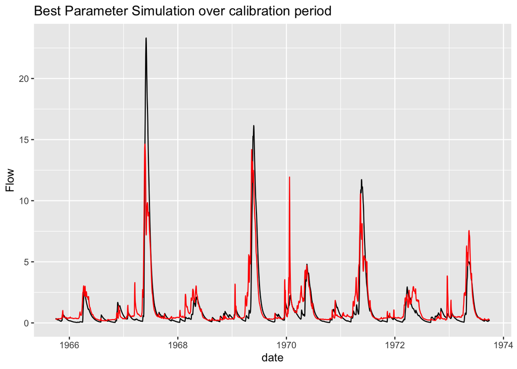

```r
# plot the flow by year for the best parameter over calibration period
ggplot(msage_calibration,
       aes(date, msage_calibration[,best_calibration$sim])) +
  geom_line()+
  geom_line(aes(date, obs), col="red")+
  labs(title = "Best Parameter Simulation over calibration period",
       y = "Flow")
```

The best simulation is S89, and the worst simulation is S15.

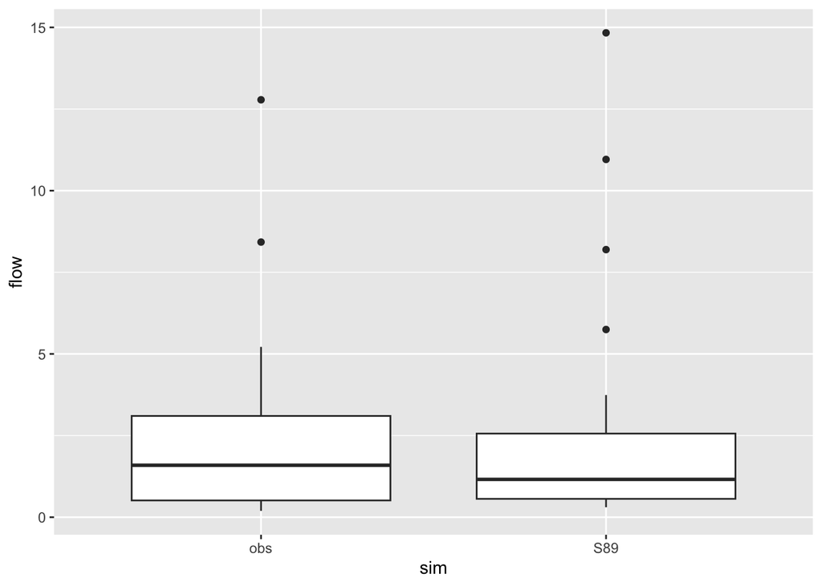

```r
# compare best and worst calibration
compruns = msage %>%
  select(best_calibration$sim, date, obs, month, day, year, wy)

# look at best and worst calibration post calibration period
#compruns = subset(compruns, wy > 1973)

compruns_mwy = compruns %>%
  select(-c(day,date, year)) %>%
  group_by(month, wy) %>%
  summarize(across(everything(), mean))

compruns_mwyl = compruns_mwy %>%
  pivot_longer(cols=!c(month,wy),
               names_to="sim",
               values_to="flow")

compruns_mwyl %>%
  subset(month==6) %>%
  ggplot(aes(sim,flow ))+
  geom_boxplot()
```

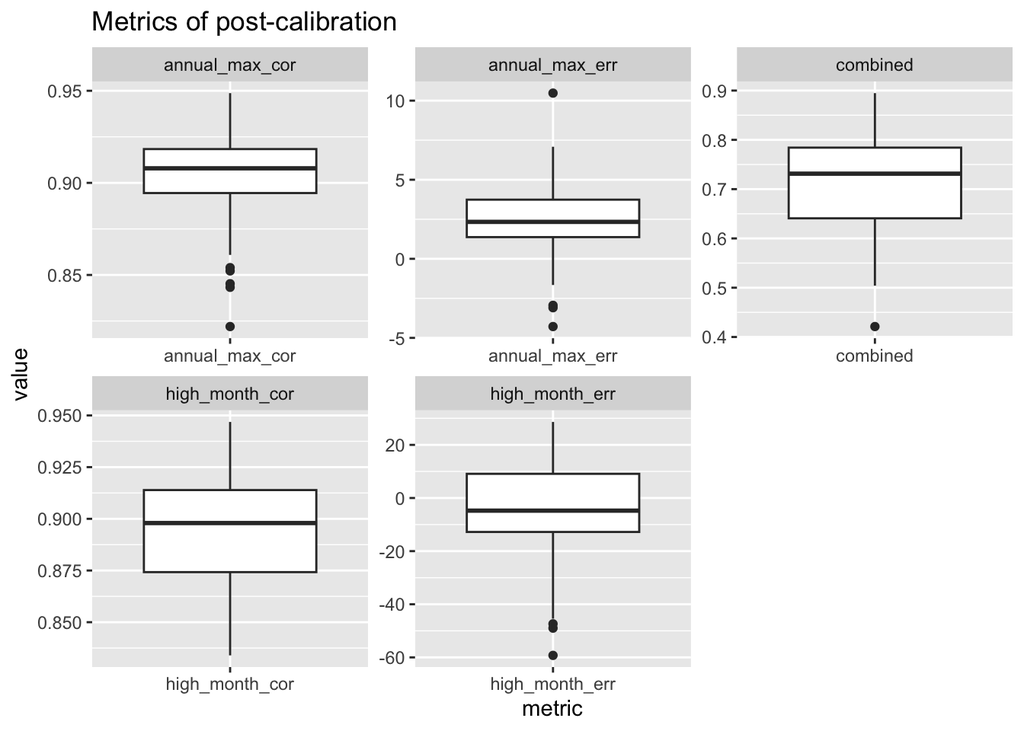

```r
# post calibration period
msage_post <-
  subset(msage, wy > 1973)

# compare pre and post calibration performance

# get metrics
res_post = msage_post %>%
  select(-date, -month, -day, -year, -wy, -obs) %>%
  # this line applies our function to the dataset
  map_df(compute_highflowmetrics_all,
         o=msage_post$obs,
         month=msage_post$month,
         day=msage_post$day,
         year=msage_post$year,
         wy=msage_post$wy)

# row that adds simulation number
res_post$sim = snames

# graph range of performance measures
resl_post = res_post %>%
  pivot_longer(-sim,
               names_to="metric",
               values_to="value")

# graph the distribution of metrics over the calibration data
ggplot(resl_post, aes(metric, value))+
  geom_boxplot()+
  facet_wrap(~metric, scales="free") +
  labs(title = "Metrics of post-calibration")
```

```r
# compare combined metric pre and post calibration
precal <- resl_calibration %>%
  filter(metric == "combined" & sim == "S33")
precal
```

```
## # A tibble: 1 × 3
##   sim   metric   value
##   <chr> <chr>    <dbl>
## 1 S33   combined 0.867
```

```r
postcal <- resl_post %>%
  filter(metric == "combined" & sim == "S33")
postcal
```

```
## # A tibble: 1 × 3
##   sim   metric   value
##   <chr> <chr>    <dbl>
## 1 S33   combined 0.827
```

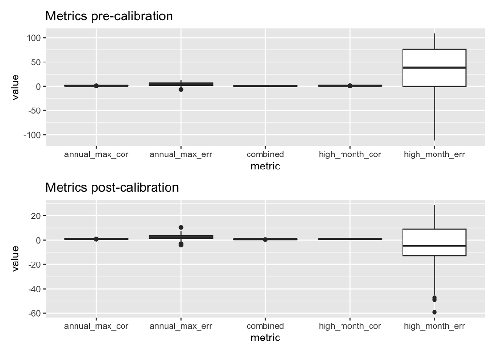

```r
# plot metrics pre calibration
pre <- ggplot(resl_calibration, aes(metric, value))+
  geom_boxplot()+
  labs(title = "Metrics pre-calibration")

# plot metrics post calibration
post <- ggplot(resl_post, aes(metric, value))+
  geom_boxplot()+
  labs(title = "Metrics post-calibration")

pre/post
```